# Loan Data from Propser by Tan Kwok Wee

## Borrower Rate/Prosper Rating Alpha vs Credit Grade/ProsperRating..Alpha. by Income Range

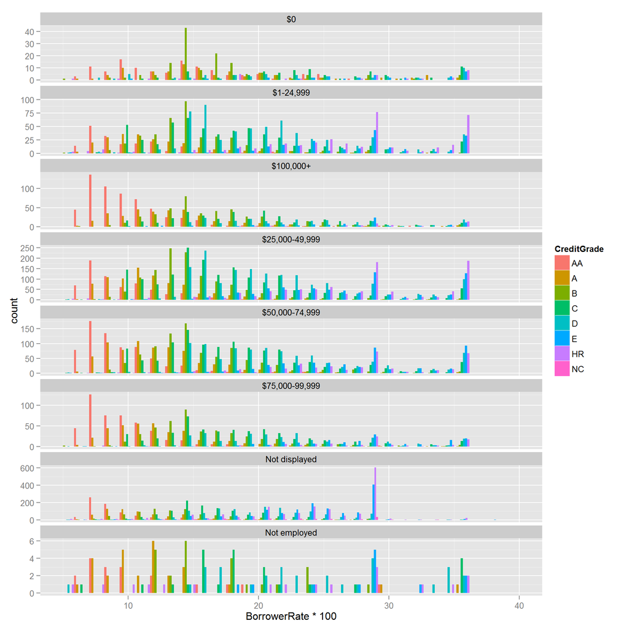

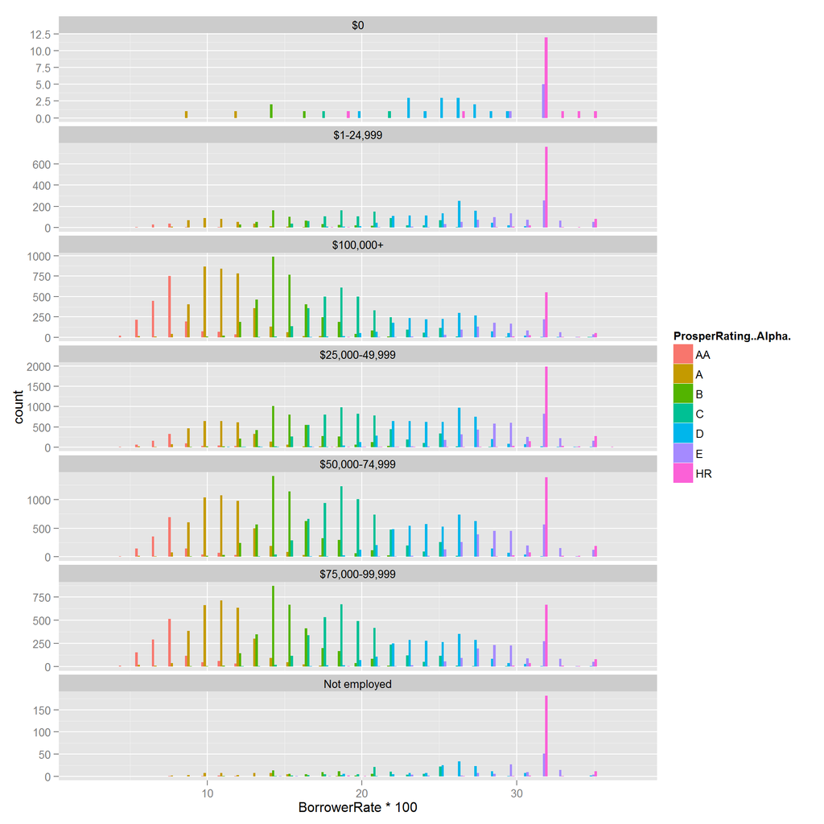

## Employment Status vs Borrower Rate by Credit Grade/ProsperRating..Alpha.

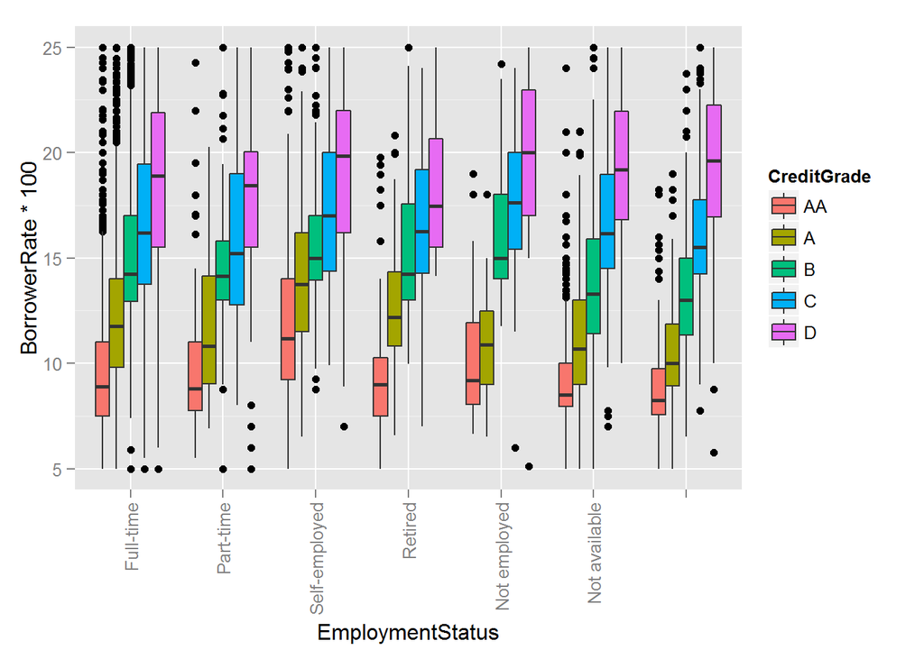

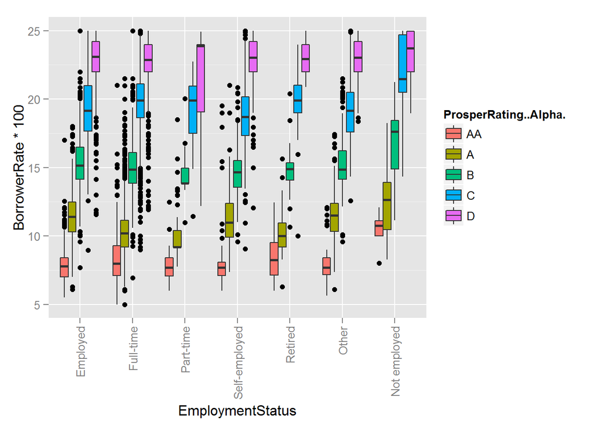

Consistently, we can see that the trend “Good Credit Grade or Prosper Rating” will result in lower borrowing rate is true.

Next, let’s understand loss by employment status grouped by CreditGrade/Proper Rating Alpha

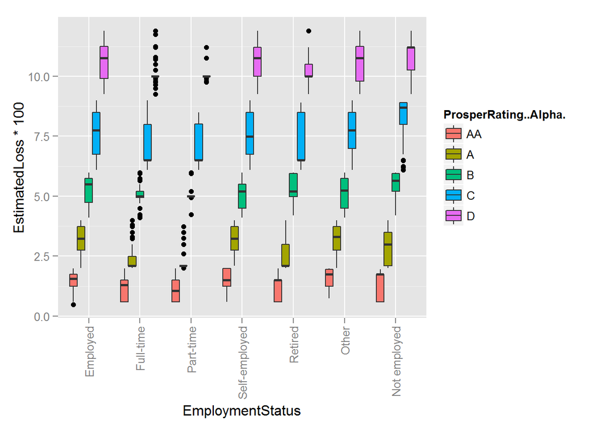

lets check if higher loan amounts will mean higher estimated loss?

## Loan Amount vs Estimated Loss by Proper Rating .. Alpha

```
##        (Intercept) LoanOriginalAmount
##      10.9346917298      -0.0003197143
```

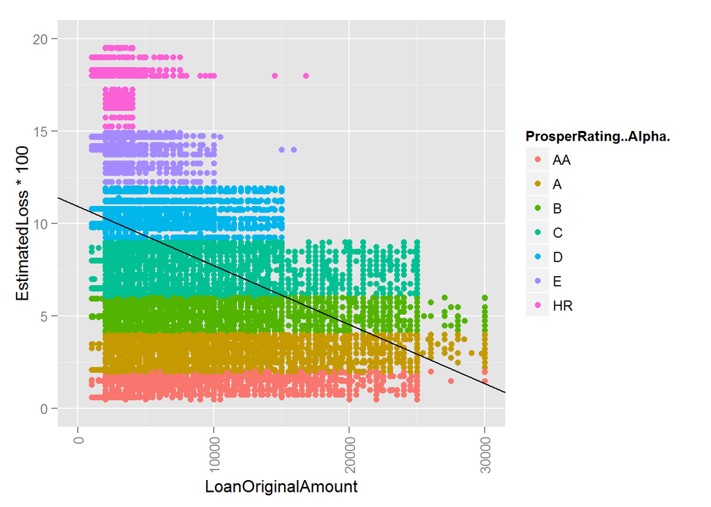

there is a negative correlation between esitmated loss vs loan original amount.

```
##                    EstimatedLoss LoanOriginalAmount
## EstimatedLoss          1.0000000         -0.4298904
## LoanOriginalAmount    -0.4298904          1.0000000
```

## Debt to Income Ratio vs Estimated Loss by Proper Rating .. Alpha

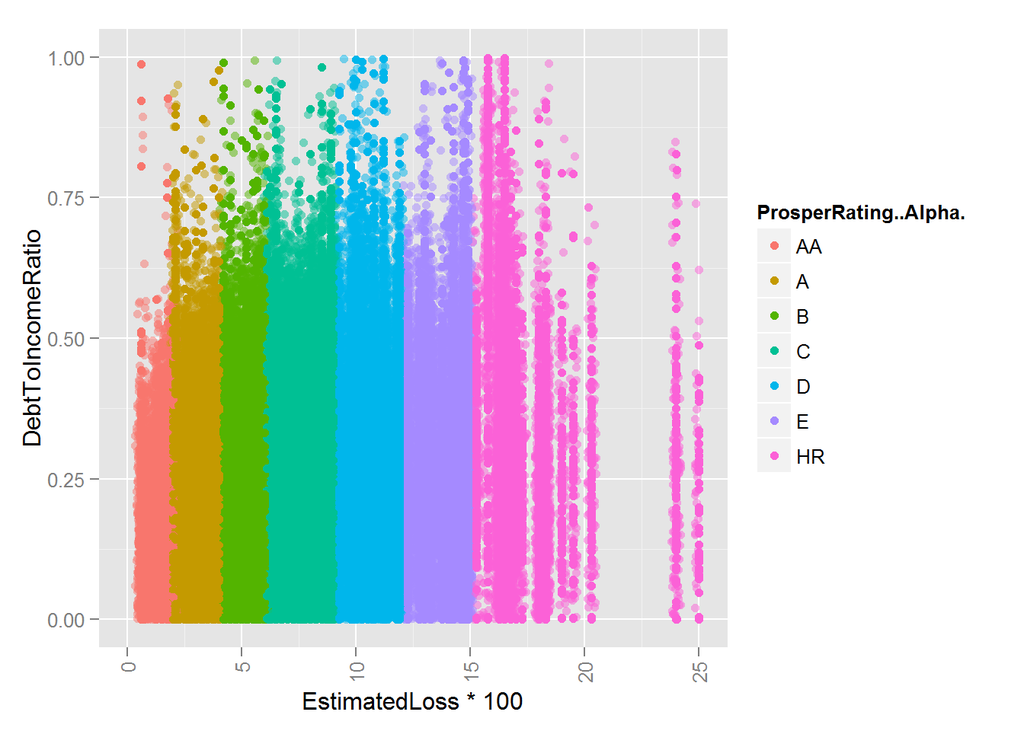

We can see that there is a positive correlation between estimated loss and Debt to income ratio.

```
##                   EstimatedLoss DebtToIncomeRatio
## EstimatedLoss        1.00000000        0.08756859
## DebtToIncomeRatio    0.08756859        1.00000000
```

## Debt to Income Ratio vs Lender Yield by Proper Rating .. Alpha

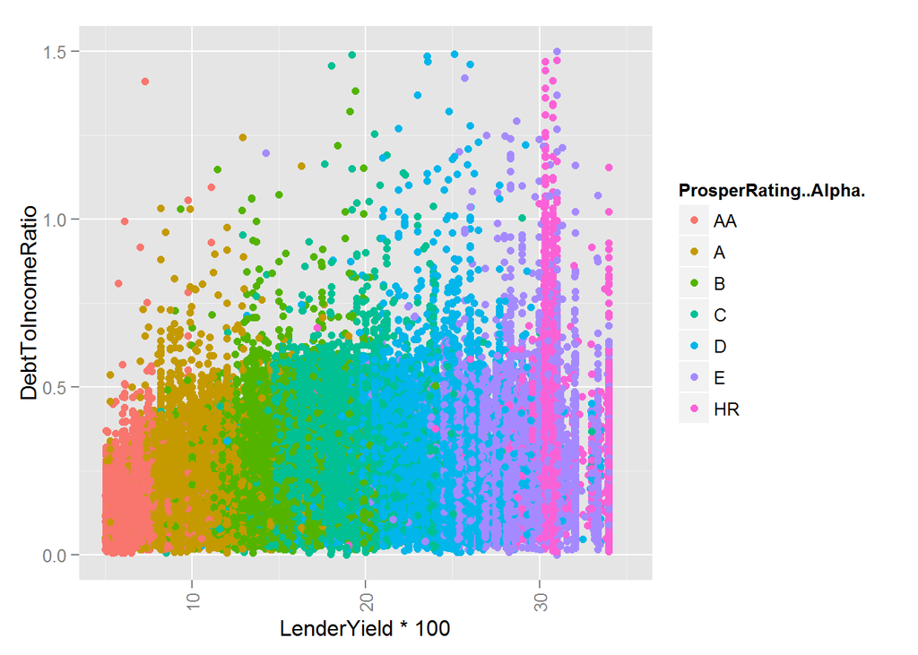

Let’s check the range of Lender Yield for this plot

```
## [1] 0.0400 0.1998
```

I would like to check if there are people with low debt to income ratio and good credit grade having loans defaulted or charged off.

## Loan status in (ChargedOff, Defaulted) vs Loan Amount and Debt to Income Ratio Facet by Prosper Rating Alpha or Credit Grade

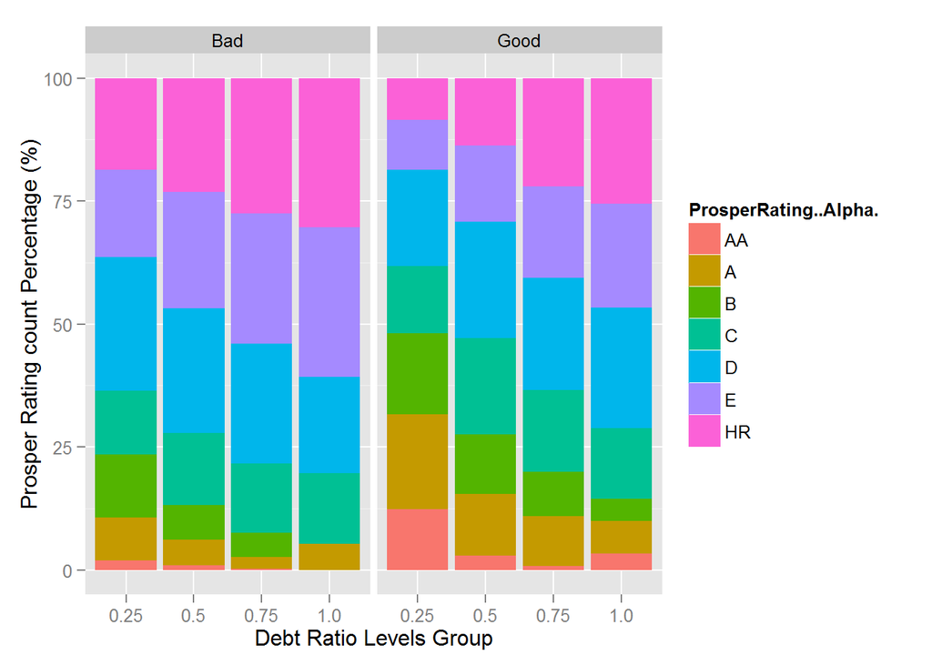

```
##    DebtToIncomeRatiolvl ProsperRating..Alpha. LsIndicator seg_Percent_cnt
## 1                  0.25                    AA         Bad     0.018972849
## 2                  0.25                     E         Bad     0.176643768
## 3                   0.5                    AA         Bad     0.010000000
## 4                   0.5                     E         Bad     0.237222222
## 5                  0.75                    AA         Bad     0.002890173
## 6                  0.75                     E         Bad     0.265895954
## 7                   1.0                     E         Bad     0.303571429
## 8                  0.25                    AA        Good     0.122869143
## 9                  0.25                     E        Good     0.100798814
## 10                  0.5                    AA        Good     0.028997021
## 11                  0.5                     E        Good     0.155511420
## 12                 0.75                    AA        Good     0.007462687
## 13                 0.75                     E        Good     0.186567164
## 14                  1.0                    AA        Good     0.033333333
## 15                  1.0                     E        Good     0.211111111
```

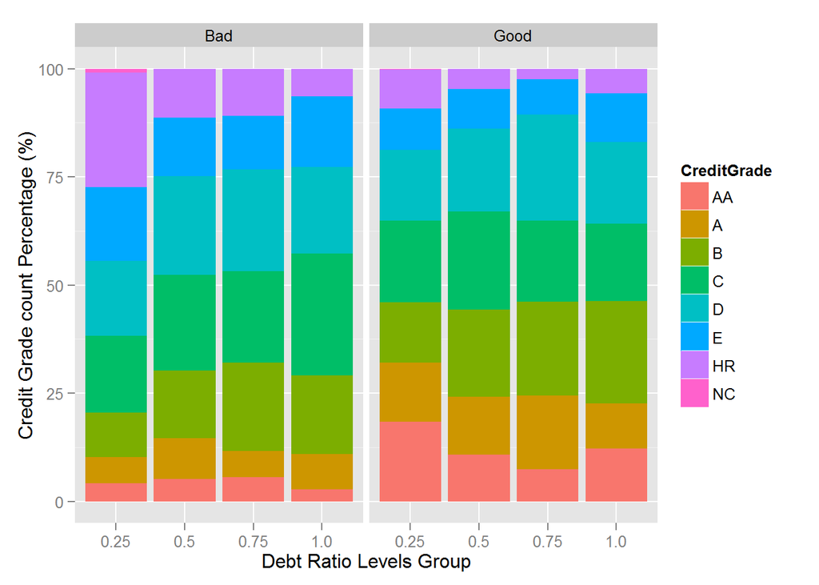

```
##    DebtToIncomeRatiolvl CreditGrade LsIndicator seg_Percent_cnt1
## 1                  0.25          AA         Bad       0.04125386
## 2                  0.25           E         Bad       0.16988793
## 3                   0.5          AA         Bad       0.05137205
## 4                   0.5           E         Bad       0.13560944
## 5                  0.75          AA         Bad       0.05555556
## 6                  0.75           E         Bad       0.12365591
## 7                   1.0          AA         Bad       0.02727273
## 8                   1.0           E         Bad       0.16363636
## 9                  0.25          AA        Good       0.18413526
## 10                 0.25           E        Good       0.09522207
## 11                  0.5          AA        Good       0.10748560
## 12                  0.5           E        Good       0.09127746
## 13                 0.75          AA        Good       0.07452340
## 14                 0.75           E        Good       0.08145581
## 15                  1.0          AA        Good       0.12264151
## 16                  1.0           E        Good       0.11320755
```

We can see that consistently borrowers with low debt to income ratio and good credit grade have lesser likelihood of defaulting as compared to other groups.

## Linear Model - Borrower Rates

```
##
## Call:
## lm(formula = BorrowerRate ~ ProsperScore + TotalProsperLoans +
##     ProsperRating..Alpha., data = ld)
##
## Residuals:
##       Min        1Q    Median        3Q       Max
## -0.142288 -0.012418 -0.001467  0.013100  0.160175
##
## Coefficients:
##                           Estimate Std. Error t value Pr(>|t|)
## (Intercept)              1.335e-01  2.263e-02   5.899 3.72e-09 ***
## ProsperScore            -2.169e-03  9.291e-05 -23.345  < 2e-16 ***
## TotalProsperLoans1      -3.593e-02  2.260e-02  -1.590   0.1119
## TotalProsperLoans2      -3.712e-02  2.260e-02  -1.643   0.1005
## TotalProsperLoans3      -3.679e-02  2.261e-02  -1.627   0.1037
## TotalProsperLoans4      -3.866e-02  2.263e-02  -1.709   0.0875 .
## TotalProsperLoans5      -3.795e-02  2.271e-02  -1.671   0.0947 .
## TotalProsperLoans6      -3.890e-02  2.299e-02  -1.692   0.0906 .
## TotalProsperLoans7      -4.573e-02  2.397e-02  -1.908   0.0564 .
## TotalProsperLoans8      -4.819e-02  3.196e-02  -1.508   0.1316
## ProsperRating..Alpha.A   3.344e-02  7.144e-04  46.811  < 2e-16 ***
## ProsperRating..Alpha.B   7.145e-02  7.872e-04  90.768  < 2e-16 ***
## ProsperRating..Alpha.C   1.118e-01  8.393e-04 133.198  < 2e-16 ***
## ProsperRating..Alpha.D   1.562e-01  8.802e-04 177.442  < 2e-16 ***
## ProsperRating..Alpha.E   2.095e-01  9.762e-04 214.655  < 2e-16 ***
## ProsperRating..Alpha.HR  2.252e-01  1.084e-03 207.703  < 2e-16 ***
## ---
## Signif. codes:  0 '***' 0.001 '**' 0.01 '*' 0.05 '.' 0.1 ' ' 1
##
## Residual standard error: 0.02259 on 19781 degrees of freedom
##   (94140 observations deleted due to missingness)
## Multiple R-squared:  0.9159, Adjusted R-squared:  0.9158
## F-statistic: 1.436e+04 on 15 and 19781 DF,  p-value: < 2.2e-16
```

We can see that prosper score, total prosper loans and propserrating.. alpha are the independent variables that are able to explain 91.59% of the variation in borrower’s rate

## Linear Model - Estimated Loss

```
##
## Call:
## lm(formula = EstimatedLoss ~ ProsperScore + TotalProsperLoans +
##     ProsperRating..Alpha., data = ld)
##
## Residuals:
##       Min        1Q    Median        3Q       Max
## -0.042743 -0.006809 -0.001074  0.005441  0.170046
##
## Coefficients:
##                           Estimate Std. Error t value Pr(>|t|)
## (Intercept)              1.548e-02  1.419e-02   1.091    0.275
## ProsperScore            -1.169e-03  5.826e-05 -20.059   <2e-16 ***
## TotalProsperLoans1       9.448e-03  1.417e-02   0.667    0.505
## TotalProsperLoans2       9.685e-03  1.417e-02   0.683    0.494
## TotalProsperLoans3       9.743e-03  1.418e-02   0.687    0.492
## TotalProsperLoans4       1.016e-02  1.419e-02   0.716    0.474
## TotalProsperLoans5       9.906e-03  1.424e-02   0.696    0.487
## TotalProsperLoans6       7.116e-03  1.441e-02   0.494    0.622
## TotalProsperLoans7       5.867e-03  1.503e-02   0.390    0.696
## TotalProsperLoans8       5.701e-03  2.004e-02   0.284    0.776
## ProsperRating..Alpha.A   1.320e-02  4.480e-04  29.474   <2e-16 ***
## ProsperRating..Alpha.B   3.207e-02  4.936e-04  64.964   <2e-16 ***
## ProsperRating..Alpha.C   5.360e-02  5.263e-04 101.858   <2e-16 ***
## ProsperRating..Alpha.D   8.188e-02  5.519e-04 148.345   <2e-16 ***
## ProsperRating..Alpha.E   1.183e-01  6.121e-04 193.270   <2e-16 ***
## ProsperRating..Alpha.HR  1.722e-01  6.798e-04 253.291   <2e-16 ***
## ---
## Signif. codes:  0 '***' 0.001 '**' 0.01 '*' 0.05 '.' 0.1 ' ' 1
##
## Residual standard error: 0.01417 on 19781 degrees of freedom
##   (94140 observations deleted due to missingness)
## Multiple R-squared:  0.9238, Adjusted R-squared:  0.9237
## F-statistic: 1.599e+04 on 15 and 19781 DF,  p-value: < 2.2e-16
```

Similarly, prosper score, total prosper loans and propserrating.. alpha are the independent variables that are able to explain 92.38% of the variation in estimated loss.

## Linear Model - Lender Yield

```
##
## Call:
## lm(formula = LenderYield ~ ProsperScore + TotalProsperLoans +
##     ProsperRating..Alpha., data = ld)
##
## Residuals:
##       Min        1Q    Median        3Q       Max
## -0.142269 -0.012419 -0.001456  0.013094  0.160198
##
## Coefficients:
##                           Estimate Std. Error t value Pr(>|t|)
## (Intercept)              1.236e-01  2.262e-02   5.461 4.79e-08 ***
## ProsperScore            -2.173e-03  9.288e-05 -23.392  < 2e-16 ***
## TotalProsperLoans1      -3.596e-02  2.259e-02  -1.591   0.1115
## TotalProsperLoans2      -3.715e-02  2.259e-02  -1.644   0.1002
## TotalProsperLoans3      -3.681e-02  2.260e-02  -1.629   0.1034
## TotalProsperLoans4      -3.868e-02  2.262e-02  -1.710   0.0873 .
## TotalProsperLoans5      -3.797e-02  2.270e-02  -1.673   0.0944 .
## TotalProsperLoans6      -3.892e-02  2.298e-02  -1.694   0.0903 .
## TotalProsperLoans7      -4.575e-02  2.396e-02  -1.909   0.0562 .
## TotalProsperLoans8      -4.823e-02  3.195e-02  -1.510   0.1312
## ProsperRating..Alpha.A   3.343e-02  7.142e-04  46.814  < 2e-16 ***
## ProsperRating..Alpha.B   7.144e-02  7.870e-04  90.781  < 2e-16 ***
## ProsperRating..Alpha.C   1.118e-01  8.390e-04 133.208  < 2e-16 ***
## ProsperRating..Alpha.D   1.562e-01  8.799e-04 177.470  < 2e-16 ***
## ProsperRating..Alpha.E   2.095e-01  9.759e-04 214.687  < 2e-16 ***
## ProsperRating..Alpha.HR  2.251e-01  1.084e-03 207.721  < 2e-16 ***
## ---
## Signif. codes:  0 '***' 0.001 '**' 0.01 '*' 0.05 '.' 0.1 ' ' 1
##
## Residual standard error: 0.02258 on 19781 degrees of freedom
##   (94140 observations deleted due to missingness)
## Multiple R-squared:  0.9159, Adjusted R-squared:  0.9159
## F-statistic: 1.437e+04 on 15 and 19781 DF,  p-value: < 2.2e-16
```

Similarly, prosper score, total prosper loans and propserrating.. alpha are the independent variables that are able to explain 91.59% of the variation in lender yield.

# Multivariate Analysis

### Were there any interesting or surprising interactions between features?

we can observe that there are people without stated monthly income with loans greater than 20,000

There is a negative correlation between esitmated loss vs loan original amount. My initial impression that greater loan amounts will affect estimated loss percentage.

### OPTIONAL: Did you create any models with your dataset? Discuss the strengths and limitations of your model.

yes, i had created 3 linear models on Borrower Rates, Estimated Loss and Lender Yield.

I had used multiple linear regression model to predict dependant variable ( BorrowerRate, EstimatedLoss) and using Adjusted R-Square to evaluate the model.

The model is simple to use and understand, but linear regression is unable to predict outliers and unable to establish causation.

# Final Plots and Summary

### Plot One

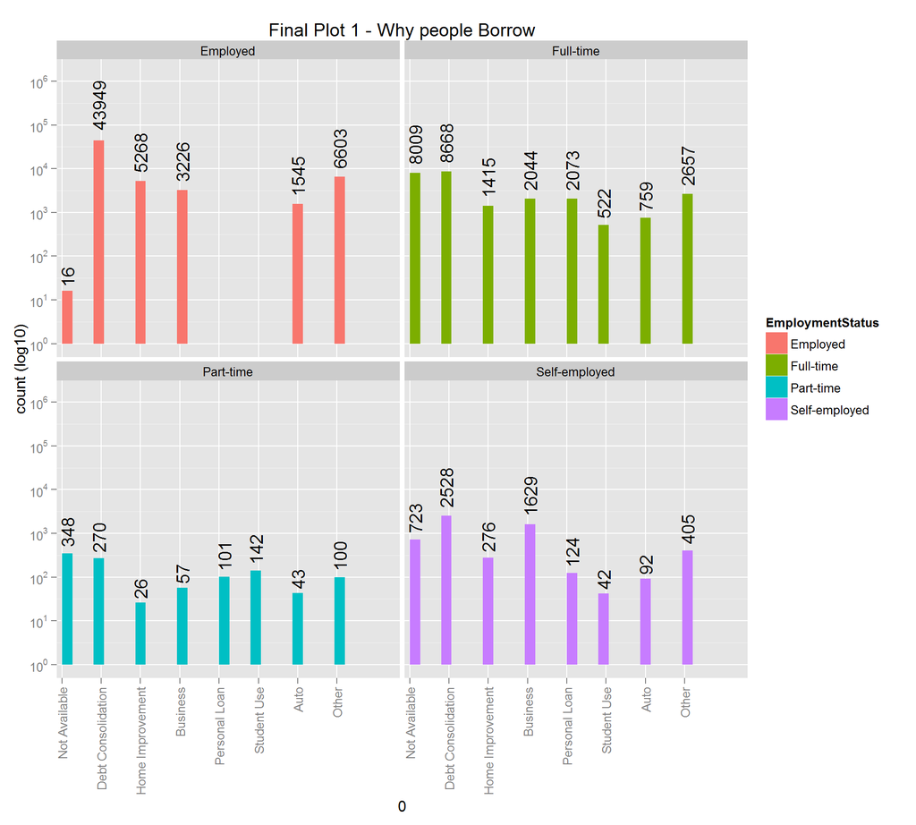

### Description One

In general, we can see a trend of people of the same employment status have the same reason for taking a loan.

From final plot one, we understand that most people do not take loans for luxury items like boats or large purchases.

### Plot Two

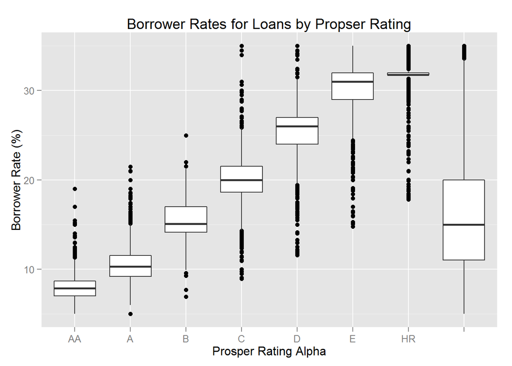

### Description Two

For Final plot 2, i subset the loans which were either completed or final payment phase to look at the historical BorrowerRate by proper rating.

It appears that people with good credit grade will have a lower borrower rate and vice versa.

```
## [1] 0.04 0.17
```

We can see that BorrowerRate ranges from 4% to 17% for Borrowers with propser rating alpha of “AA” (Best Prosper Rating) and debt to income ratio below 1.0.

I feel that there are good investment opportunities by funding prosper loans as the borrower rates are high.

### Plot Three

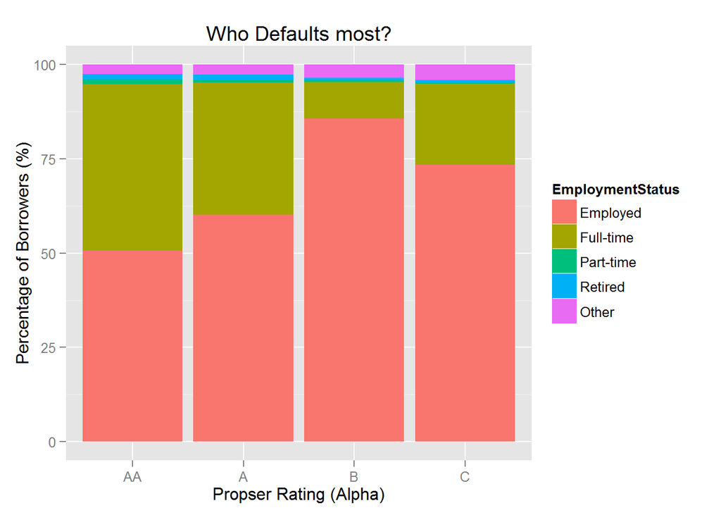

### Description Three

Final Plot 3 shows a subset of loans data which were defaulted or charged off for all employment status with good Prosper Rating Alpha (AA,A,B,C) and Debt to income ratio of less than 1.0.

We can see that borrowers whom are self-employed are not shown in the plot.  
This means that this group of borrowers had never defaulted on their loans.

```
##   ProsperRating..Alpha. EmploymentStatus pReS_cnt
## 1                     C         Employed      524
## 2                     B         Employed      460
## 3                     A         Employed      224
## 4                    AA         Employed       39
## 5                     C        Full-time      154
## 6                     A        Full-time      130
```

People with Prosper Rating C with employment status as employed are most likely to default from data set i had created.

```
## [1] 0.050 0.185
```

also, we can see that these segment of “self-employed” borrowers with best prosper credit rating of “AA” have lender yields of 5% to 18.5%.  
I would think that if i would invest in propser loans, i would invest by lending to self-employed borrowers with “AA” propser lending as the yields are attractive and risk is historically low.

# Reflection

After doing this project that i realize that R is a powerful visualization and statistical computation tool. It is very easy to compute statistics and graphs with the help of libraries like plyr, dylr and ggplot.

I had trouble understanding the variables and selecting what variables to analyze.  
Therefore, I had to more spend time reviewing almost 70% of the variables inorder to decide which variables would fit the analysis.  
However, as i worked with the data set and understanding the variables, i found out that i was searching in an ocean and was not going anywhere.  
That is when i realized, that i have to focus on defining the purpose of my project. So i took a break and spent time to defining the purpose and generate the questions for the project.  
Being an avid investor, i was intriged by the risk and reward of this new peer lending system. Once, the purpose and questions are defined, the project went on smoothly.

Based on the models created we can see that 3 variables prosper score, total prosper loans and propserrating.. alpha has correlation of over 90% with BorrowerRate, Estimated Loss and Lender yield.

To improve the analysis i will need to incorporate intrest rates/data for traditional channels of credit ( credit card, bank loans and etc .. ).

In the future, after i had completed the Machine Learning course, I would like to build a model to predict prosper score, determine users’ probability of default and lending yields.

Personally, I feel that Prosper Loans is a viable alternative investment.

After this project, i feel that i equiped with the necessary knowledge to explore other datasets.

# Reference

- [How To Find Relationship Between Variables, Multiple Regression] (http://www.statsoft.com/textbook/multiple-regression)
- [Prosper - company Overview] (https://www.prosper.com/about)
- [GGplot from yhat] (http://ggplot.yhathq.com/)
- [R Studio - rmarkdown reference](http://www.rstudio.com/wp-content/uploads/2015/03/rmarkdown-reference.pdf)
- [R Graphics Cookbook] (http://www.cookbook-r.com/Graphs/index.html)
- [Wikipedia - List of U.S. states and territories by population](http://en.wikipedia.org/wiki/List_of_U.S._states_and_territories_by_population)
- [inside r - scales package documentation] (http://www.inside-r.org/packages/cran/scales/docs/trans_breaks)
- [R Style Guide] (http://adv-r.had.co.nz/Style.html)
- [R pandoc Markdown] (http://rmarkdown.rstudio.com/authoring_pandoc_markdown.html#paragraphs)
- [Stackoverflow - how to change correlation text size in ggpairs] (http://stackoverflow.com/questions/8599685/how-to-change-correlation-text-size-in-ggpairs)
- [cran - color brewer] (http://cran.r-project.org/web/packages/RColorBrewer/index.html)
- [color brewer] (http://colorbrewer2.org/)